# Data Cleaning and Data Preparation - Phase 2

Ankita Guha and Kara Marsh

April 22, 2018

```r
library(VIM)
```

Let’s read the previously cleaned CSV File into a seperate data frame to proceed with the cleaning process. So the datafile from Kaggle, was blank in method_name. So let’s try to put “NA” inside the dataframe and then try to see if we can replace those NA’s with something relevant.

```r
air_quality1 <- read.csv(file='data/cleaned2_AQ.csv',
                         na.strings = c("", "NA"))
```

Let’s check if all of our variables are cleaned and does not contain any missing values or data that might mislead our analysis.

```r
sum(is.na.data.frame(air_quality1))
```

```
## [1] 71174
```

So, looks like our dataframe does have NA values. But since it is a huge dataframe let’s try to visualize if we have any missing data pattern just to be double sure.

```r
sapply(air_quality1, function(x) sum(is.na(x)))
```

```
##                       X          parameter_code                latitude
##                       0                       0                       0
##               longitude          parameter_name         sample_duration
##                       0                       0                       0
##             metric_used             method_name                    year
##                       0                   71174                       0
##        units_of_measure              event_type       observation_count
##                       0                       0                       0
##     observation_percent  completeness_indicator         valid_day_count
##                       0                       0                       0
##      required_day_count  exceptional_data_count certification_indicator
##                       0                       0                       0
##       num_obs_below_mdl         arithmetic_mean arithmetic_standard_dev
##                       0                       0                       0
##         first_max_value        second_max_value         third_max_value
##                       0                       0                       0
##        fourth_max_value  ninety_nine_percentile ninety_eight_percentile
##                       0                       0                       0
##  ninety_five_percentile       ninety_percentile seventy_five_percentile
##                       0                       0                       0
##        fifty_percentile          ten_percentile                 address
##                       0                       0                       0
##              state_name             county_name     date_of_last_change
##                       0                       0                       0
```

It looks like all of the NA values are from method_name.

```r
make.true.NA <- function(x) if(is.character(x)||is.factor(x)){
                                  is.na(x) <- x %in% c("NA", "N/A","???"); x} else {
                                  x}
```

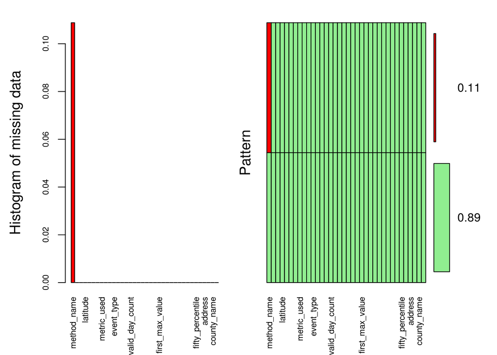

```
##
##  Variables sorted by number of missings:
##                 Variable     Count
##              method_name 0.1088088
##                        X 0.0000000
##           parameter_code 0.0000000
##                 latitude 0.0000000
##                longitude 0.0000000
##           parameter_name 0.0000000
##          sample_duration 0.0000000
##              metric_used 0.0000000
##                     year 0.0000000
##         units_of_measure 0.0000000
##               event_type 0.0000000
##        observation_count 0.0000000
##      observation_percent 0.0000000
##   completeness_indicator 0.0000000
##          valid_day_count 0.0000000
##       required_day_count 0.0000000
##   exceptional_data_count 0.0000000
##  certification_indicator 0.0000000
##        num_obs_below_mdl 0.0000000
##          arithmetic_mean 0.0000000
##  arithmetic_standard_dev 0.0000000
##          first_max_value 0.0000000
##         second_max_value 0.0000000
##          third_max_value 0.0000000
##         fourth_max_value 0.0000000
##   ninety_nine_percentile 0.0000000
##  ninety_eight_percentile 0.0000000
##   ninety_five_percentile 0.0000000
##        ninety_percentile 0.0000000
##  seventy_five_percentile 0.0000000
##         fifty_percentile 0.0000000
##           ten_percentile 0.0000000
##                  address 0.0000000
##               state_name 0.0000000
##              county_name 0.0000000
##      date_of_last_change 0.0000000
```

```r
explore_missingdata <- aggr(air_quality1,
                            col=c('lightgreen','red'),
                            numbers=TRUE,
                            sortVars=TRUE,
                            labels=names(data),
                            cex.axis=.7,
                            gap=3,
                            ylab=c("Histogram of missing data","Pattern"))
```

So, we have missing data for method_name. Well, precisely it was blank data and it was not even NA, so we had to figure a way to actually put NA values inside the dataframe and then proceed with our analysis.

Let’s clear some of our data frame to save on memory space

```r
rm(explore_missingdata, make.true.NA)
```

Okay, so after doing a little EDA we realized that this missing data has a lot of infleunce in our overall dataframe. So we decided to replace them with an easily identifiable variable content name as “Missing Data from Kaggle” so as to make it easy to spot on.

```r
air_quality1$method_name <- as.character(air_quality1$method_name)

air_quality1$method_name <- ifelse(is.na(air_quality1$method_name),
                                   'Missing Data From Kaggle',
                                   air_quality1$method_name)
```

Finally let’s check the summary of our dataframe, if we got any NA value or not!

```r
sapply(air_quality1, function(x) sum(is.na(x)))
```

```
##                       X          parameter_code                latitude
##                       0                       0                       0
##               longitude          parameter_name         sample_duration
##                       0                       0                       0
##             metric_used             method_name                    year
##                       0                       0                       0
##        units_of_measure              event_type       observation_count
##                       0                       0                       0
##     observation_percent  completeness_indicator         valid_day_count
##                       0                       0                       0
##      required_day_count  exceptional_data_count certification_indicator
##                       0                       0                       0
##       num_obs_below_mdl         arithmetic_mean arithmetic_standard_dev
##                       0                       0                       0
##         first_max_value        second_max_value         third_max_value
##                       0                       0                       0
##        fourth_max_value  ninety_nine_percentile ninety_eight_percentile
##                       0                       0                       0
##  ninety_five_percentile       ninety_percentile seventy_five_percentile
##                       0                       0                       0
##        fifty_percentile          ten_percentile                 address
##                       0                       0                       0
##              state_name             county_name     date_of_last_change
##                       0                       0                       0
```

Let’s write our cleaned file now for next level of analysis

```r
write.csv(air_quality1, file = "data/cleaned_AQ.csv")
```

Let’s free some of our dataframe

```r
rm(air_quality1)
```

Okay, so looks like we are ready for our first level of EDA!